# KidDraw-Analysis1

Bria Long

11/24/2017

## Load data and do basic preprocessing.

```r
# Source some helper functions
source("/Users/brialong/Documents/GitHub/kiddraw/analysis/museumdraw/helper_code/useful.R")
## Read in data outputs from python - stroke numbers, intensity, bounding boc, etc.
d <- read.csv("preprocessed_data/museumdraw_E1c_imageData.csv");

# get rid of drwaings without age - these were when we were testing the interface.
d <- d %>%
  filter(!is.na(age))

# make new variable name with image name for joining with recognition data
d$imNameShort = paste(d$category, '_sketch','_', d$age,'_', d$session_id,'.png', sep="");
## Read in data outputs from turk data - true/false recognition with 21AFC
r <- read.csv("preprocessed_data/museumdraw_E1c_recognitionData.csv");

## check we have the right lengths
length(d$session_id)==length(unique(r$imageName));
```

```
## [1] TRUE
```

## Take a look at the raw rating data as a sanity check

Confusions look more or less reasonable

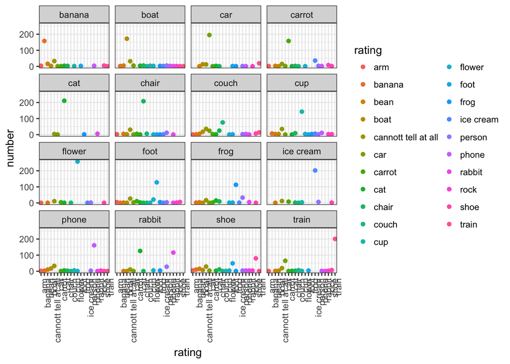

```r
dataFrameR=as.data.frame(r);

ratingConfusions <- dataFrameR %>%
  dplyr::group_by(category, rating)  %>%
  dplyr::summarize(number = n())

ratingConfusions$rating=as.factor(ratingConfusions$rating)
ggplot(ratingConfusions, aes(rating,number, color=rating))+
  geom_point() +
  facet_wrap(~category) +
  theme(axis.text.x = element_text(angle = 90, hjust = 1))
```

## Preprocess data and join datasets

```r
# add special column for when people selected "can't tell at all" during ratings; not separated out in current analyses
r$cantTell=(r$rating=="cannott tell at all")

## Get the percent recognized for each drawing
corbyItem <- r %>%
  dplyr::group_by(imNameShort) %>%
  dplyr::summarize(meanCorrect = mean(correct), propCantTell = mean(cantTell))

## Joint the two datasets together
joint=join(d,corbyItem);
# treat session_id and category as factors
joint$session_id=as.factor(joint$session_id)
joint$category=as.factor(joint$category)

## for use below with glmer analyses (which never converged...)
joinedRatings=join(r,d)
```

## Basic descriptives

```r
# Number of drawings
numDrawings=length(joint$imNameShort)

# Number of drawers
numDrawers=length(unique(joint$session_id))

# Average age of drawers
avgAge=round(mean(d$age[d$trial_num==2]),2) ## 2 is the first non-practice trial, use d structure here since it is doesn't repeat for each rating trial

# Drawings by category
drawingsByCategory <- joint %>%
  dplyr::group_by(category) %>%
  dplyr::summarize(count = n())

# Drawings by age
ageDescriptives <- joint %>%
  dplyr::group_by(age) %>%
  dplyr::summarize(count = n(), meanCorrect = mean(meanCorrect), propCantTell = mean(propCantTell))

# Percent "can't tell at all" by age category
ageCantTellOut=round(ageDescriptives$propCantTell*100,1) # not reported in abstract, but interesting.

# Percent correct by age category
ageCorrOut=format(round(ageDescriptives$meanCorrect*100,1), nsmall=1)
```

# Exploratory plots

## How much do num_strokes / intensity / duration covary with eachother?

In all of the following plots, one point = one drawing

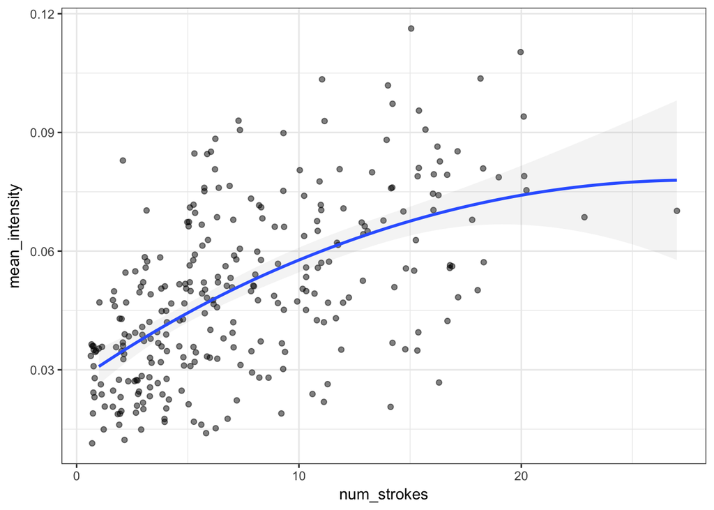

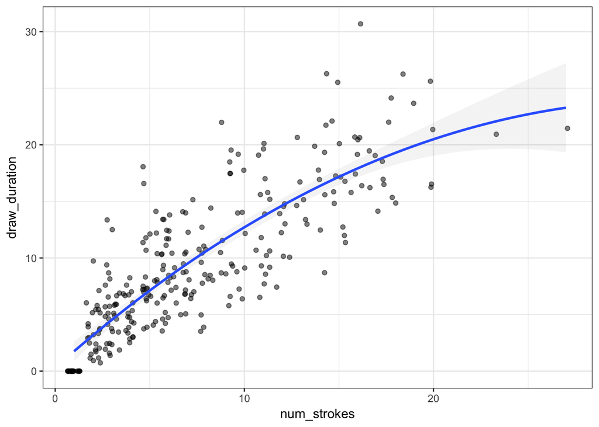

## Are darker drawings better recognized?

Interesting - probably somewhat up to a point. Last points are creating a big tail on the loess function but probably more ink = more information = better recognized

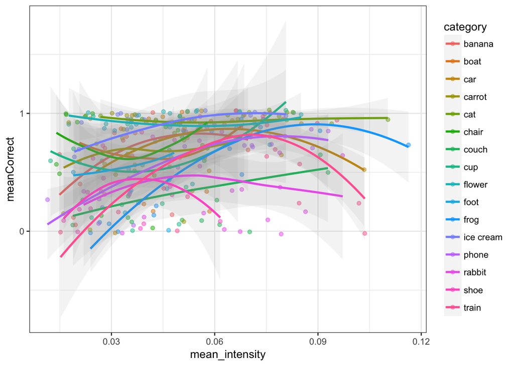

## Are drawings with more strokes better recognized?

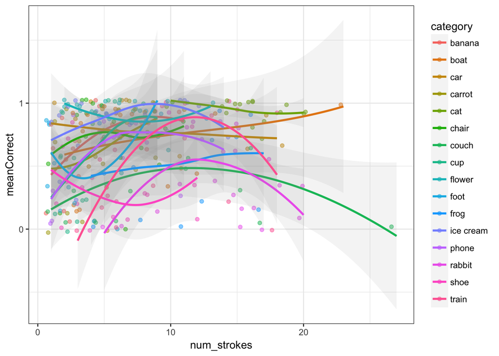

## Are drawings that take longer better recognized?

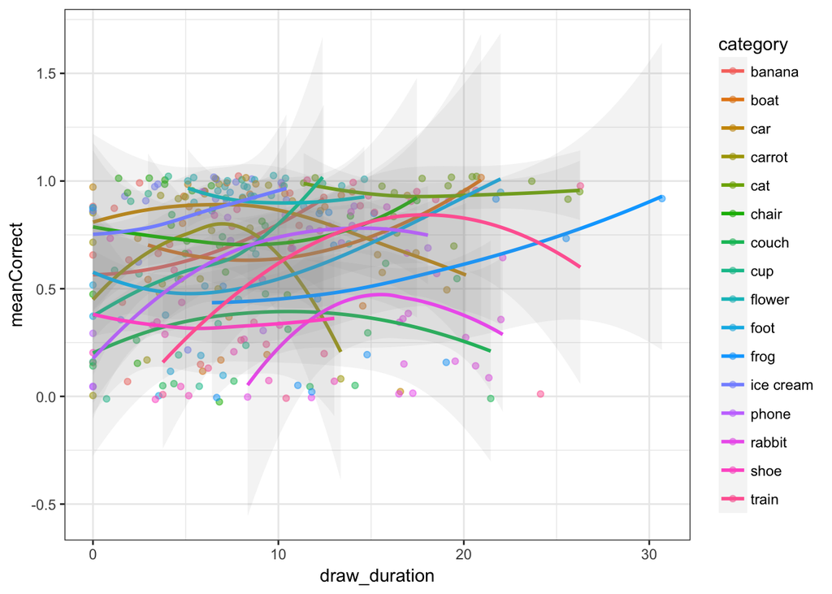

## Are drawings better recognized with age?

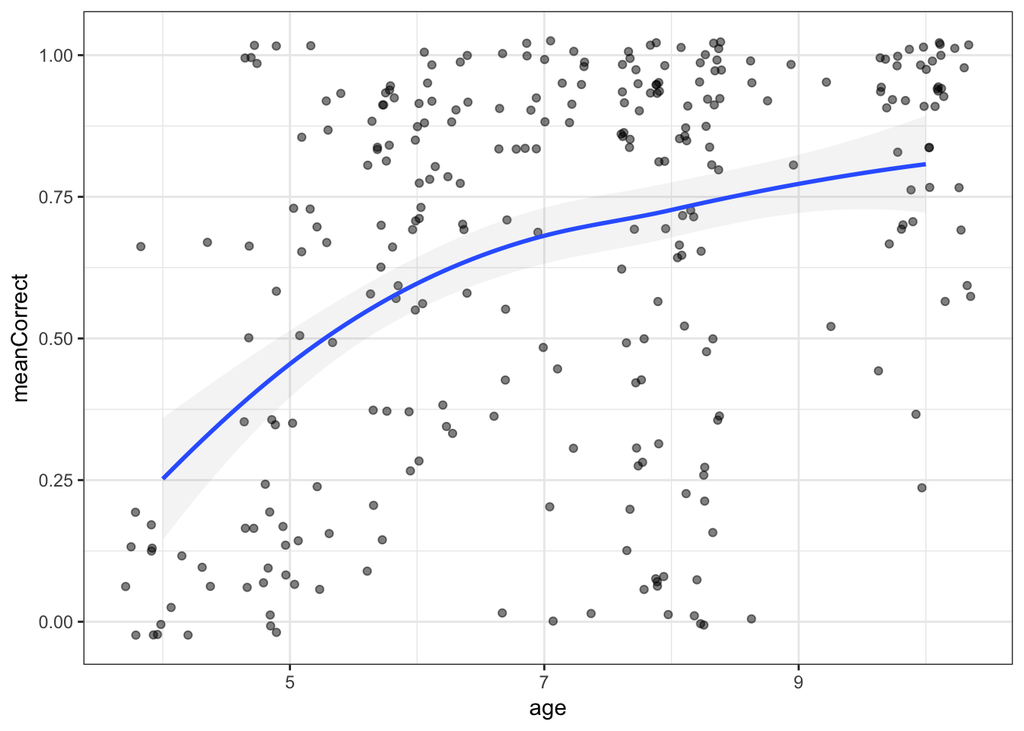

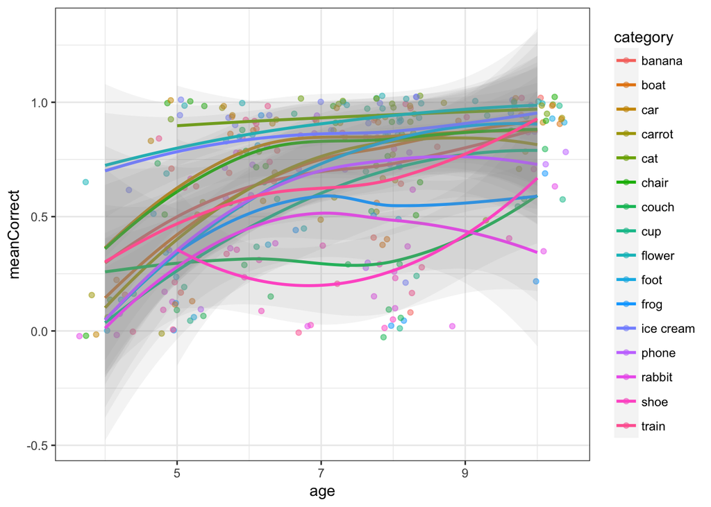

## How does this trend break down by catergory?

Some items show a stronger trend than others but overall looks good

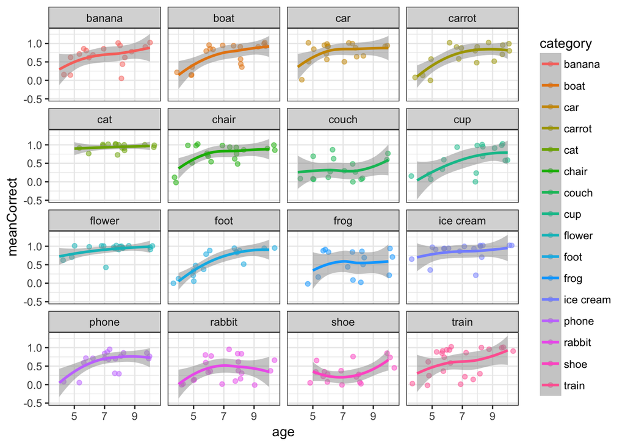

## How much variance is there per participant (i.e., per child drawer?)

Looks like there are some kids that are very bad or very good at drawing, but there is also a fair number of kids with wide distributions

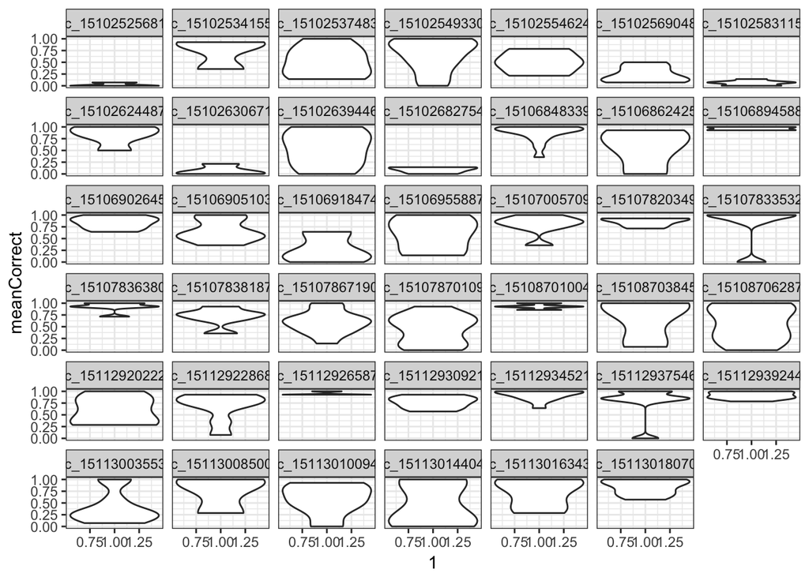

# Inferential statistics: data preprocessing

```r
# First norm DV by arc sine transformation since it is a proportion
arcSinTransform <- function (data) {
  out = (asin(sqrt(data)))
}
joint$normCorrect=arcSinTransform(joint$meanCorrect)

# Rescale  continuous predictor variables to get rid of warnings when fitting with only ML
colInd <- grep("mean_intensity",names(joint))
joint[,colInd]=scale(joint[,colInd])

rm(colInd); colInd <- grep("draw_duration",names(joint))
joint[,colInd]=scale(joint[,colInd])

rm(colInd); colInd <- grep("num_strokes",names(joint))
joint[,colInd]=scale(joint[,colInd])

rm(colInd); colInd <- grep("age",names(joint))
joint[,colInd]=scale(joint[,colInd])
```